# Classification Trees

Son Nguyen

### Reading Materials

- Max Kuhn. Chapter 14. Section 14.1

### Decision Boundary in Classification

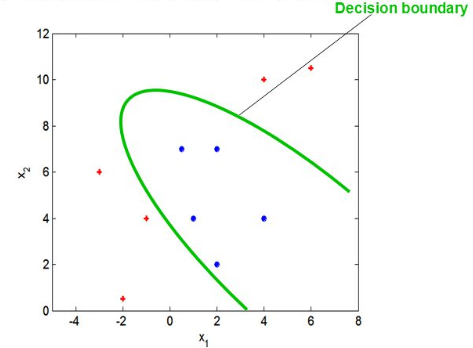

Classification is a process of finding the **decision boundary** that best separate two classes

### Decision Boundary in Classification

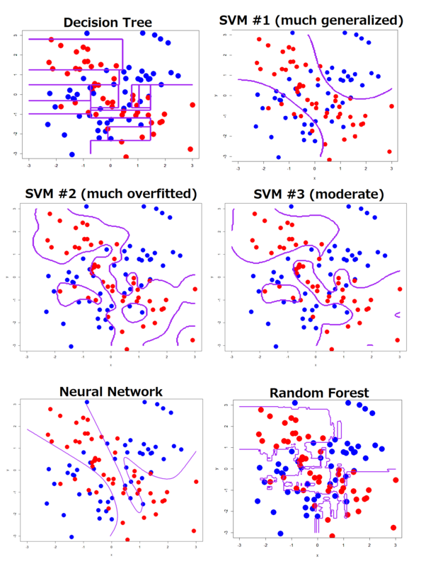

SVM = Support Vector Machine

### Decision Tree

- Decision Tree for classification is **Classification Tree**
- Decision Tree for Regression is **Regression Tree**

### Example of Classification Tree

[Link](http://graphics8.nytimes.com/images/2008/04/16/us/0416-nat-subOBAMA.jpg)

### Example of Classification Tree

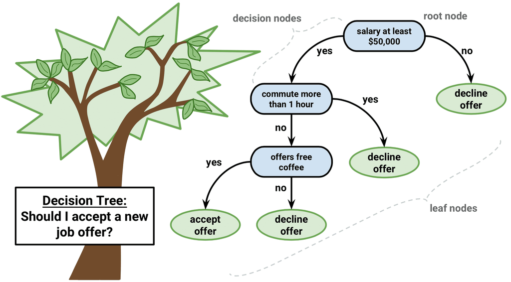

### Example of Classification Tree

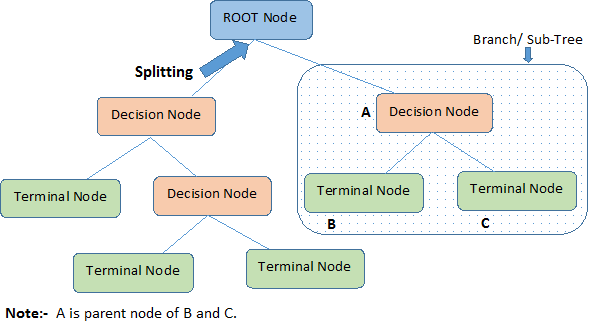

### Classification Tree

- In two dimension, classification Tree's decision boundary is a collection of horiontal and vertical line

### Data

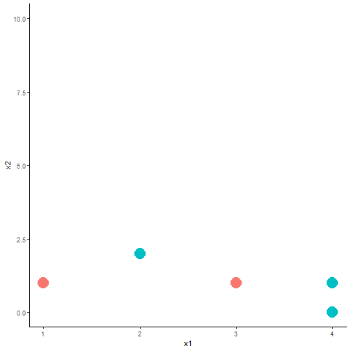

- The tree starts by a vertical or horizontal line that **best** seperate the data
- **Question**: Find a vertical line that best seperate **red** and **green**.

### One way to seperate the reds and greens

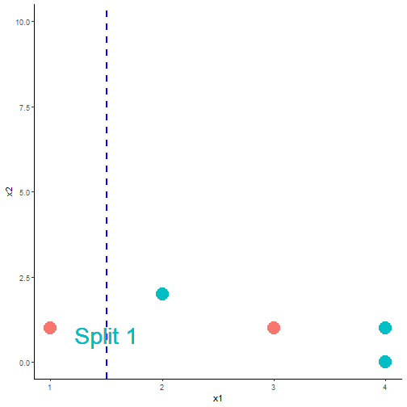

### One way to seperate the reds and greens

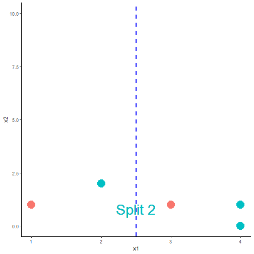

### One way to seperate the reds and greens

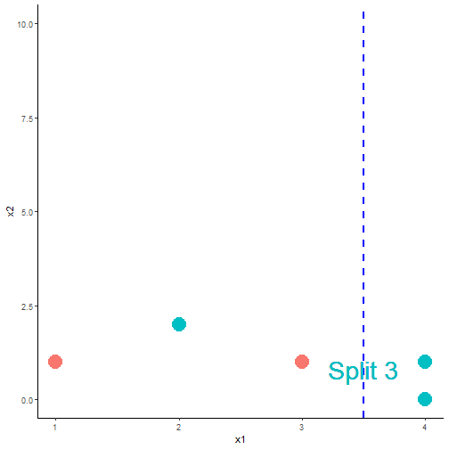

### Question

- **Question**: Which is the best split?

### Partial Answer

- It looks like Split 1 and 3 are better than Split 2 since it misclassifies less
- Which is the better split between Split 1 and Split 3?
- We need to find a way to measure *how good a split is*

### Impurity Measure

- The impurity of a node (**a node = a subset of the data or the original data**) measure how uncertain the node is.
- For example, node A with 50% reds and 50% greens would be more uncertained than node B with 90% reds and 10% greens. Thus, node A has greater impurity than node B.
- More uncertained \( = \) Greater impurity

### Impurity Measure

- A split that *gains* more impurity is the **better split**!

### Impurity Gain

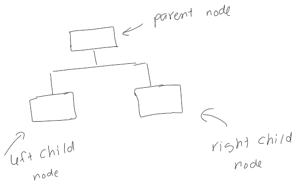

\[ IG = I_{parent} - \frac{N_{left}}{N}I_{left}-\frac{N_{right}}{N}I_{right} \]

- IG is Impurity Gain of the split
- \( N_{left} \) and \( N_{right} \) are the number of points in the left child node and right child node, respectively.
- \( N_{left}+N_{right}=N \)

### Impurity Measure

- Impurity can be measured by: classification error, Gini Index, and Entropy.

### Impurity Measure

- Let \( p_0 \) and \( p_1 \) be the proportion of class 0 and class 1 in a node.

\[ \begin{aligned} {\text{By Classification Error: }} I &= min\{p_0, p_1\} \\ {\text{By Gini Index: }} I&= 1 - p_0^2-p_1^2 \\ {\text{By Entropy: }} I &= -p_0 \log_2(p_0)-p_1\log_2(p_1) \end{aligned} \]

### Calculation

- Let's calculate the impurity gain of the three splits to decide which split is the best

### IG By Classification Error

- Let **green** and **red** be class 0 and class 1, respectively.

For Split 1: \( N = 5, N_{left} =1, N_{right} = 4 \)

- Node *parent,* A: \( p_0 = \frac{2}{5}, p_1 = \frac{3}{5} \). Thus, \( I_{A} = \text{min}(\frac{2}{5}, \frac{3}{5}) = \frac{2}{5} \)
- Node *child left,* L: \( p_0 = \frac{0}{1} = 0, p_1 = \frac{1}{1} = 1 \). Thus, \( I_{L} = \text{min}(0, 1) = 0 \)
- Node *child right,* R: \( p_0 = \frac{3}{4}, p_1 = \frac{1}{4} \). Thus, \( I_{R} = \text{min}(\frac{3}{4}, \frac{1}{4}) = \frac{1}{4} \)
- Impurity Gain of Split 1:

\[ IG = \frac{2}{5} - \frac{1}{5} \cdot 0-\frac{4}{5} \cdot \frac{1}{4} = 0.2 \]

### IG By Classification Error

For Split 2: \( N = 5, N_{left} =2, N_{right} = 3 \)

- Node *parent,* A: \( p_0 = \frac{2}{5}, p_1 = \frac{3}{5} \). Thus, \( I_{A} = \text{min}(\frac{2}{5}, \frac{3}{5}) = \frac{2}{5} \)
- Node *child left,* L: \( p_0 = \frac{1}{2}, p_1 = \frac{1}{2} \). Thus, \( I_{L} = \frac{1}{2} \)
- Node *child right,* R: \( p_0 = \frac{2}{3}, p_1 = \frac{1}{3} \). Thus, \( I_{R} = \text{min}(\frac{2}{3}, \frac{1}{3}) = \frac{1}{3} \)
- Impurity Gain of Split 2:

\[ IG = \frac{2}{5} - \frac{2}{5} \cdot \frac{1}{2}-\frac{3}{5} \cdot \frac{1}{3} = 0 \]

### IG By Classification Error

For Split 3: \( N = 5, N_{left} =3, N_{right} = 2 \)

- Node *parent,* A: \( p_0 = \frac{2}{5}, p_1 = \frac{3}{5} \). Thus, \( I_{A} = \text{min}(\frac{2}{5}, \frac{3}{5}) = \frac{2}{5} \)
- Node *child left,* L: \( p_0 = \frac{1}{3}, p_1 = \frac{2}{3} \). Thus, \( I_{A} = \text{min}(\frac{1}{3}, \frac{2}{3}) = \frac{1}{3} \)
- Node *child right,* R: \( p_0 = \frac{2}{2}, p_1 = \frac{0}{2} \). Thus, \( I_{R} = \text{min}(1,0) = 0 \)
- Impurity Gain of Split 3:

\[ IG = \frac{2}{5} - \frac{3}{5} \cdot \frac{1}{3}-\frac{2}{5} \cdot 0 = 0.2 \]

### Comparing IG By Classification Error

|  | IG |
| --- | --- |
| Split 1 | 0.2 |
| Split 2 | 0 |
| Split 3 | 0.2 |

- By classification error, Split 1 and Split 3 are tie as the best because they have the same impurity gain.

### IG By Gini Index

For Split 1: \( N = 5, N_{left} =1, N_{right} = 4 \)

- Node *parent,* A: \( p_0 = \frac{2}{5}, p_1 = \frac{3}{5} \). Thus, \( I_{A} = 1 - (\frac{2}{5})^2-(\frac{3}{5})^2 = 0.48 \)
- Node *child left,* L: \( p_0 = \frac{0}{1} = 0, p_1 = \frac{1}{1} = 1 \). Thus, \[ I_{L} = 1 -0^2-1^2 = 0 \]
- Node *child right,* R: \( p_0 = \frac{3}{4}, p_1 = \frac{1}{4} \). Thus, \[ I_{R} = 1-(\frac{3}{4})^2-(\frac{1}{4})^2 = 0.375 \]
- Impurity Gain of Split 1:

\[ IG = 0.48 - \frac{1}{5} \cdot 0-\frac{4}{5} \cdot 0.375 = 0.18 \]

### IG By Gini Index

For Split 2: \( N = 5, N_{left} =2, N_{right} = 3 \)

- Node *parent,* A: \( p_0 = \frac{2}{5}, p_1 = \frac{3}{5} \). Thus, \( I_{A} = 1-(\frac{2}{5})^2- (\frac{3}{5})^2 = 0.48 \)
- Node *child left,* L: \( p_0 = \frac{1}{2}, p_1 = \frac{1}{2} \). Thus, \( I_{L} = 1- (\frac{1}{2})^2-(\frac{1}{2})^2=0.5 \)
- Node *child right,* R: \( p_0 = \frac{2}{3}, p_1 = \frac{1}{3} \). Thus, \( I_{R} = 1-(\frac{2}{3})^2 -(\frac{1}{3})^2 = 0.44 \)
- Impurity Gain of Split 2:

\[ IG = 0.48 - \frac{2}{5} \cdot \frac{1}{2}-\frac{3}{5} \cdot 0.44 = 0.016 \]

### IG By Gini Index

For Split 3: \( N = 5, N_{left} =3, N_{right} = 2 \)

- Node *parent,* A: \( I_{A} = 0.48 \)
- Node *child left,* L: \( p_0 = \frac{1}{3}, p_1 = \frac{2}{3} \). Thus, \( I_{A} = 1-(\frac{1}{3})^2 -(\frac{2}{3})^2 = 0.44 \)
- Node *child right,* R: \( p_0 = \frac{2}{2}, p_1 = \frac{0}{2} \). Thus, \( I_{R} = 1-0^2-1^2 = 0 \)
- Impurity Gain of Split 3:

\[ IG = 0.48 - \frac{3}{5} \cdot 0.44 - \frac{2}{5} \cdot 0 = 0.216 \]

### Comparing IG By Gini Index

|  | IG |
| --- | --- |
| Split 1 | 0.18 |
| Split 2 | 0.016 |
| Split 3 | 0.216 |

- By Gini Index, Split 3 is the best because it has the greatest impurity gain.

### IG By Entropy

For Split 1: \( N = 5, N_{left} =1, N_{right} = 4 \)

- Node *parent,* A: \( p_0 = \frac{2}{5}, p_1 = \frac{3}{5} \). Thus, \( I_{A} = - log_2(\frac{2}{5})-log_2(\frac{3}{5}) = 0.971 \)
- Node *child left,* L: \( p_0 = \frac{0}{1} = 0, p_1 = \frac{1}{1} = 1 \). Thus, \( I_{L} = 0 \)
- Node *child right,* R: \( p_0 = \frac{3}{4}, p_1 = \frac{1}{4} \). Thus, \[ I_{R} = -\frac{3}{4} \cdot log_2(\frac{3}{4})-\frac{1}{4} \cdot log_2(\frac{1}{4}) = 0.811 \]
- Impurity Gain of Split 1:

\[ IG = 0.971 - \frac{1}{5} \cdot 0-\frac{4}{5} \cdot 0.811 = 0.322 \]

### IG By Entropy

For Split 2: \( N = 5, N_{left} =2, N_{right} = 3 \)

- Node *parent,* A: \( p_0 = \frac{2}{5}, p_1 = \frac{3}{5} \). Thus, \( I_{A} = 0.971 \)
- Node *child left,* L: \( p_0 = \frac{1}{2}, p_1 = \frac{1}{2} \). Thus, \( I_{L} = - log_1(\frac{1}{2})-log_2(\frac{1}{2})=1 \)
- Node *child right,* R: \( p_0 = \frac{2}{3}, p_1 = \frac{1}{3} \). Thus, \( I_{R} = -\frac{2}{3} \cdot log_2(\frac{2}{3}) -\frac{1}{3} \cdot log_2(\frac{1}{3}) = 0.918 \)
- Impurity Gain of Split 2:

\[ IG = 0.971 - \frac{2}{5} \cdot 1-\frac{3}{5} \cdot 0.918 = 0.02 \]

### IG By Entropy

For Split 3: \( N = 5, N_{left} =3, N_{right} = 2 \)

- Node *parent,* A: \( I_{A} = 0.971 \)
- Node *child left,* L: \( p_0 = \frac{1}{3}, p_1 = \frac{2}{3} \). Thus, \( I_{A} = -log_2(\frac{1}{3}) -log_2(\frac{2}{3}) = 0.918 \)
- Node *child right,* R: \( p_0 = \frac{2}{2}, p_1 = \frac{0}{2} \). Thus, \( I_{R} = 0 \)
- Impurity Gain of Split 3:

\[ IG = 0.971 - \frac{3}{5} \cdot 0.918 - \frac{2}{5} \cdot 0 = 0.42 \]

### Comparing IG By Entropy

|  | IG |
| --- | --- |
| Split 1 | 0.322 |
| Split 2 | 0.02 |
| Split 3 | 0.42 |

- By Gini Index, Split 3 is the best because it has the greatest impurity gain.

### Comparing Impurity Measures

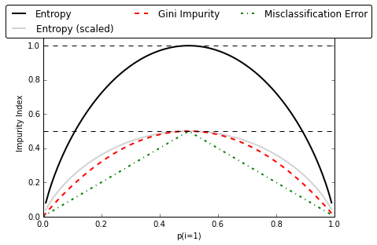

- Relation between impurity and the class probabilities. All impurity measures are maximized at **\( p_1 =1/2 \)** and minimized at **\( p_1 = 0 \)** and **\( p_1=1 \)**.

### Another Example

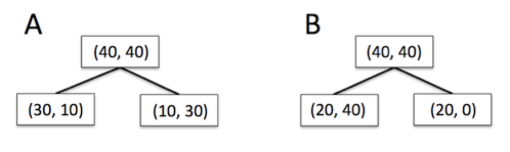

- Which split is better?

### Decide the best split using Chi-Square test of Independence

- Besides impurity gain, one can use the Chi-square, \( \chi^2 \), test of independence to decide the best split.

### Review of Chi-Square test of Independence

- Let \( X \) and \( Y \) be two categorical variables.
- We want to test if \( X \) and \( Y \) are independent/associated
  - \( H_0 \): \( X \) and \( Y \) are independent
  - \( H_{\alpha}: \) \( X \) and \( Y \) are dependent
- Test statistic:

\[ \sum\frac{(e_i-o_i)^2}{e_i} \sim \chi^2 \text{ distribution with degree of freedom} (n-1)(m-1) \]

### Review of Chi-Square test of Independence

- In our context, the greater the \( \chi^2 \) value, the smaller the \( p-value \)
- The smaller the \( p-value \), the more dependent the two variables are. Thus the better the split is.
- Therefore, we look for the split with the **greatest \( \chi^2 \) value.**

### Applying to Our Example

- We will calculate the \( \chi^2 \) values of the three splits.
- The best split is the split with the greatest \( \chi^2 \) value.

### Split 1

|  | Greens | Reds |  |
| --- | --- | --- | --- |
| Left Branch | 0 (Cell 1) | 1 (Cell 2) | 1 |
| Right Branch | 3 (Cell 3) | 1 (Cell 4) | 4 |
|  | 3 | 2 |  |

\[ \chi^2 = \frac{(e_1-o_1)^2}{e_1}+\frac{(e_2-o_2)^2}{e_2}+\frac{(e_3-o_3)^2}{e_3}+\frac{(e_4-o_4)^2}{e_4} \]

- \( i=1 \) (Cell 1): \( e_1 = \frac{1\cdot 3}{5} \), \( o_1 = 0 \)
- \( i=2 \) (Cell 2): \( e_2 = \frac{1\cdot 2}{5} \), \( o_2 = 1 \)
- \( i=3 \) (Cell 3): \( e_3 = \frac{3\cdot 4}{5} \), \( o_3 = 3 \)
- \( i=4 \) (Cell 4): \( e_4 = \frac{2\cdot 4}{5} \), \( o_4 = 1 \)
- Plug in, we have: \[ \chi^2 = 1.875 \]

### Split 2

|  | Greens | Reds |  |
| --- | --- | --- | --- |
| Left Branch | 1 (Cell 1) | 1 (Cell 2) | 2 |
| Right Branch | 2 (Cell 3) | 1 (Cell 4) | 3 |
|  | 3 | 2 |  |

\[ \chi^2 = \frac{(e_1-o_1)^2}{e_1}+\frac{(e_2-o_2)^2}{e_2}+\frac{(e_3-o_3)^2}{e_3}+\frac{(e_4-o_4)^2}{e_4} \]

- \( i=1 \) (Cell 1): \( e_1 = \frac{2\cdot 3}{5} \), \( o_1 = 1 \)
- \( i=2 \) (Cell 2): \( e_2 = \frac{2\cdot 2}{5} \), \( o_2 = 1 \)
- \( i=3 \) (Cell 3): \( e_3 = \frac{3\cdot 3}{5} \), \( o_3 = 2 \)
- \( i=4 \) (Cell 4): \( e_4 = \frac{3\cdot 2}{5} \), \( o_4 = 1 \)
- Plug in, we have: \[ \chi^2 = 0.139 \]

### Split 3

|  | Greens | Reds |  |
| --- | --- | --- | --- |
| Left Branch | 1 (Cell 1) | 2 (Cell 2) | 3 |
| Right Branch | 2 (Cell 3) | 0 (Cell 4) | 2 |
|  | 3 | 2 |  |

\[ \chi^2 = \frac{(e_1-o_1)^2}{e_1}+\frac{(e_2-o_2)^2}{e_2}+\frac{(e_3-o_3)^2}{e_3}+\frac{(e_4-o_4)^2}{e_4} \]

- (Cell 1): \( e_1 = \frac{2\cdot 3}{5} \), \( o_1 = 1 \)
- (Cell 2): \( e_2 = \frac{2\cdot 2}{5} \), \( o_2 = 2 \)
- (Cell 3): \( e_3 = \frac{3\cdot 3}{5} \), \( o_3 = 2 \)
- (Cell 4): \( e_4 = \frac{3\cdot 2}{5} \), \( o_4 = 0 \)
- Plug in, we have: \[ \chi^2 = 2.222 \]

### Comparing the three splits

|  | \( \chi^2 \) |
| --- | --- |
| Split 1 | 1.875 |
| Split 2 | 0.139 |
| Split 3 | 2.222 |

- Split 3 is the best because it has the greatest \( \chi^2 \)!

### Logworth

- The quality of the split can be measured by **Logworth**
- Formula: \[ logworth = -log(p\text{_}value) \]
- The greater the logworth, the better the split

### Logworth

|  | \( \chi^2 \) | p-value | logworth |
| --- | --- | --- | --- |
| Split 1 | 1.875 | 0.114 | 0.943 |
| Split 2 | 0.139 | 0.998 | 0.0008 |
| Split 3 | 2.222 | 0.088 | 1.055 |

- Greatest \( \chi^2 \) = Lowest \( p-value \) = Greatest logworth = Best Split
- Split 3 is the best split!

### What happens after the first split?

- After the first split, the data are divided into to subsets.
- The splitting process is repeated for each subset.
- The process ends when a stopping criteria is satisfied

### Stopping Criteria

- Minimum Leaf Size: The minimum of observations in the leaves
- Maximum Number of Leaves
- Maximum Depth
- Others

### Stopping Criteria

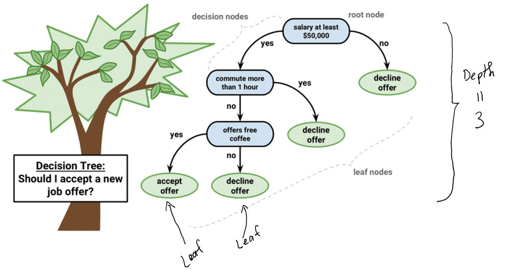

### Decision Tree Algorithm - How to grow a tree

- Step 1: Calculate the impurity gain or \( p-value \) of all possible splits at all variables
- Step 2: Select the split that give the maximum impurity gain or lowest \( p-value \) to split the data into two subdata \( D_1 \) and \( D_2 \)
- Repeat *Step 1* and *Step 2* to both \( D_1 \) and \( D_2 \).
- Until a stopping criteria is satisfied

### Complexity of Decision Tree

- A complexity of a tree can be measured by the number of leaves the tree has
- The more leaves a tree has, the more complex the tree is.
- A complex tree may be **overfitted**, i.e. having low training error but high testing error.

### Prunning a tree

- For any given data, one can construct a tree that achives 0 misclassification on training data
- After growing the tree one needs to prune it to avoid overfittted

### Prunning a tree

- The tree with maximum number of leaves is called the **maximal tree** (still satisfied the stopping rule)
- From the **maximal tree**, leaves are cut down, one by one, to obatined all possible subtrees
- The subtree with lowest error on validation data, is the **optimal tree**

### Maximal vs Optimal Tree

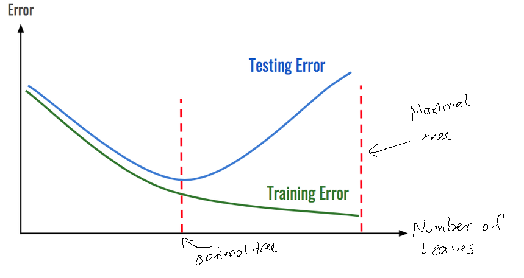

### Example of Tree Prunning

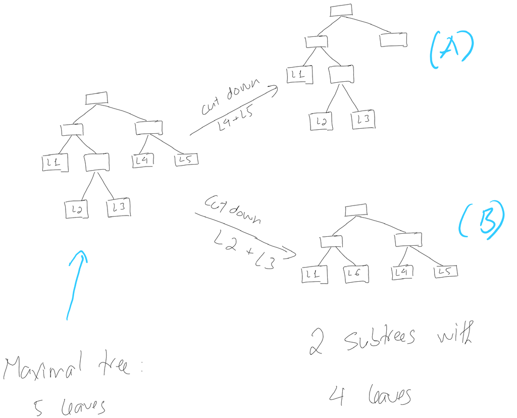

### Example of Tree Prunning

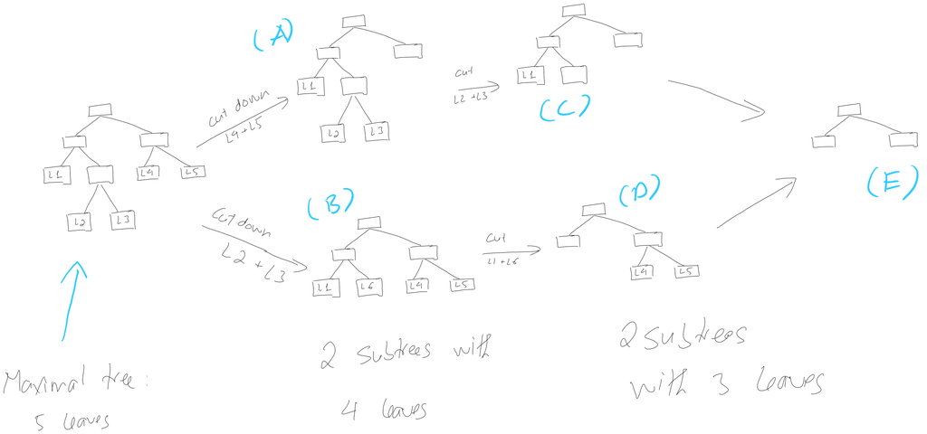

- All the subtrees A, B, C, D, and E will be validated with the validation data to find the **optimal tree**
- The **optimal tree** could be the **maximal tree**!

### Question

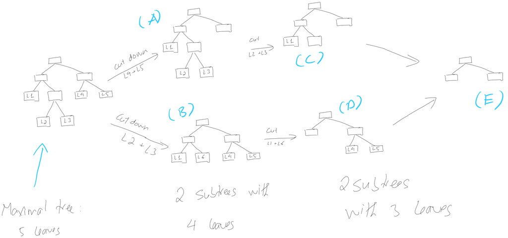

- What if both B and C give the lowest error on the validation data? Which tree should be selected as the final model?